# Manhattan Property Sales Analysis

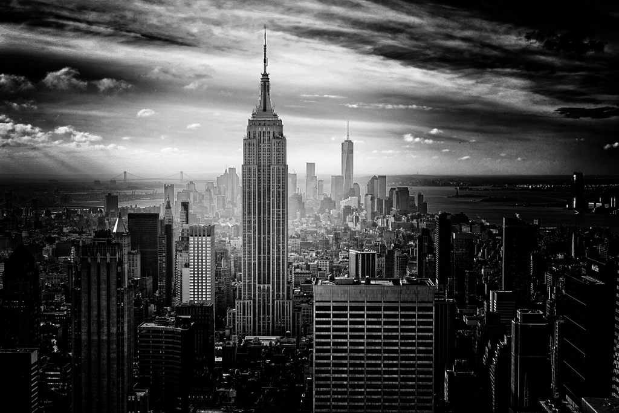

# Introduction

New York City is known for being among the most expensive cities in the world to live in, and not to mention in regard to buying the real estate properties. The property market in Manhattan, out of the seven boroughs of NYC have long been, undoubtedly, the most pricey and the most sought-after one. The purpose of this market analysis is to find out answers to questions: is there any variable that would largely determine the sale prices of the properties? If not, what variables would significantly influence the sale price; what variables do not have much impact on the finalization of the sale price?

# Data Source

This report is based on the rolling sales dataset scraped from NYC Government’s Department of Finance. The latest update of this dataset was in November 2019.  
*https://www1.nyc.gov/site/finance/taxes/property-rolling-sales-data.page*

# Packages

Packages used for coding are listed as follows.  
*“rmdformats”*: to import the theme pacakge for the markdown file  
*“readxl”*: to load the data  
*“tidyverse”*: to import a collection of R packages for data science that includes dplyr, ggplot2, tibble, readr, tidyr and purr packages  
*“lubridate”*: to make smoother conduct on date and time variables, for example, by using the ymd() function  
*“formattable”*: to do the data preview section  
*“magrittr”*: to decrease development time and to improve readability and maintainability of code  
*“knitr”*: to control the output, for example, by using the kable() functoin  
*“modelr”*: to model functions  
*“plotly”*: to plot  
*“corrplot”*: to draw the correlation plots  
*“pwr”*: to conduct power analysis  
*“gridExtra”*: to combine multiple graphs

```r
library(rmdformats) #theme package
library(readxl) #to load the data
library(tidyverse)
library(dplyr)
library(lubridate)
library(formattable) #to do data preview
library(magrittr)
library(knitr)
library(modelr)
library(plotly)
library(corrplot)
library(pwr)
library(gridExtra)
```

# Data Exploration & Preparation

## Data Import and Basic Data Exploration

*From dim() function, we could see that this dataset originally includes 17751 observations, and 21 variables.*  
*From the names() function, we could get an idea of how the names of variables are stored - pretty important since there are 21 variables of them and some of them are identical in terms of wording.*  
*From the str() function, we could get the data types for the variables included - and for the ordered factors and factors, the number of levels/classes included.*  
*From the summary() function, we could get an idea of the distribution of variables, and also information such as if there is any NA’s and would it be a big issue.*

```r
manhattan <- read_excel("rollingsales_manhattan.xls")

# hide the results of these codes for output purposes
#dim(manhattan)
#names(manhattan)
#str(manhattan)
#summary(manhattan)
```

## Data Cleaning

1. “Borough” is labeled as “1” throughout this dataset, which means “Manhattan” in New York City, and does not necessarily provide any valuable information for this case. Get rid of this column. As there are NA’s throughout the columns named “EASE-MENT” and “Apartment Number”. Remove these two columns as well.

```r
manhattan <- manhattan %>%
  select(-BOROUGH, -`EASE-MENT`, -`APARTMENT NUMBER`)
```

2. The column “Building Class Category” has the category number and title merged together in one cell - split this column into two columns as “Building Class Category Num” and “Building Class Category”.

```r
manhattan <- manhattan %>%
  separate(col = "BUILDING CLASS CATEGORY", into = c("BUILDING CLASS CATEGORY NUM", "BUILDING CLASS CATEGORY"), sep = 3)
```

3. Now create a new column called “Building Age” based on “Year Built” so as to make the variable “Year Built” more useful in future endeavor.

```r
manhattan <- manhattan %>%
  mutate(`BUILDING AGE` = 2019 - `YEAR BUILT`)
```

4. Check and remove duplicates. From the result, there are 1091 observations duplicates, which would not necessarily take up a big proportion of the size of the original dataset. Remove them. The resulting dataset now contains 16660 observations and 20 variables.

```r
# Check.
#manhattan %>% filter(duplicated(manhattan) == TRUE) %>% nrow()

# Remove.
manhattan <- unique(manhattan)
```

5. Type conversions: “Year built”, “Building Class Category”, “Building Class Category Num”, “Building class at present”, “Buidling class at time of sale”, “Zip code”, “Tax Class at Present”, and “Tax Class at time of sale” should be “factor”; “Block”, “Lot”, and “Zipcode” should be in “chr” format; “Sale Date” should be in “date” format so as to have more practical utility.

```r
# Convert to factors.
fct <- c(2,3,4,7,9,15,16,17)
manhattan %<>% mutate_at(fct, funs(as.factor(.)))

# Convert to characters.
chr <- c(5,6,9)
manhattan %<>% mutate_at(chr, funs(as.character(.)))

# Convert to date.
manhattan$`SALE DATE` <- ymd(manhattan$`SALE DATE`)
```

6. As for the missing values, check how many NA’s are included in each column at the moment. From the result, we could see that “Tax class at present”, “Building class at present”, “Zip code”, “Year built”, and interchangebly, “Building age” contain missing values. Since only five (actually, four) variables contain NA’s, remove them.

```r
# Check NA's by column.
#colSums(is.na(manhattan))

manhattan <- manhattan %>%
  filter(is.na(manhattan$`BUILDING CLASS AT PRESENT`) == FALSE)

manhattan <- manhattan %>%
  filter(is.na(manhattan$`ZIP CODE`) == FALSE)
```

```r
# Count zeroes in sale price.
# manhattan %>% filter(`SALE PRICE` == 0) %>% nrow()

#Create separate datasets for further study.
manhattan_allsp <- manhattan %>% filter(manhattan$`SALE PRICE` == 0)

manhattan_clean <- manhattan %>% filter(!manhattan$`SALE PRICE` == 0)
```

8. For numeric variables “Land square feet” and “Gross square feet”, Also, check if there is any zero in it. The results are: 12274 0’s in land square feet, while there are 6582 0’s in gross square feet. For definitions of these two terms: gross square feet generally refers to the total square feet of a space, and is often used to calculate the rent. This is an interesting finding. At the moment, leave these two variables as the way they are.

```r
# Check zeroes in land square feet.
#manhattan_clean %>% filter(manhattan_clean$`LAND SQUARE FEET` == 0) %>% nrow()

# Check zeroes in gross square feet.
#manhattan_clean %>% filter(manhattan_clean$`GROSS SQUARE FEET` == 0) %>% nrow()
```

9. Plus, for numeric variables “residential units”, “commercial units”, and “total units” - check if they contain zero values. There are many zeroes: 12546 0’s in residential units, 12796 0’s in commerical units, and 12337 0’s in total units. So, no removing would be conducted at this phase for these three variables in case these zeroes would provide insights.

```r
# Check zeroes in land square feet.
#manhattan_clean %>% filter(manhattan_clean$`RESIDENTIAL UNITS` == 0) %>% nrow()

# Check zeroes in gross square feet.
#manhattan_clean %>% filter(manhattan_clean$`COMMERCIAL UNITS` == 0) %>% nrow()

#manhattan_clean %>% filter(manhattan_clean$`TOTAL UNITS` == 0) %>% nrow()
```

10. Now deal with the zero values in “year built”. Since there are not many of them - drop them.

```r
manhattan_clean <- manhattan %>%
  filter(manhattan$`YEAR BUILT` != 0)
```

11. Add in a column extracting the month of the year at the time of sale.

```r
manhattan_clean$`SALE MONTH` <- as.factor(months(manhattan_clean$`SALE DATE`))
```

## Data Preview

This is created for the audience to have an overall idea of the final dataset that the following parts of the report is based on. Click on the variables to get the top ten-ranked observations in regard to the variable of choices.

```r
head(manhattan_clean, n = 50) %>%
  formattable() %>%
  as.datatable(options = list(dom = 't', scrollX = TRUE, scrollCollapse = TRUE))
```

|  | NEIGHBORHOOD | BUILDING CLASS CATEGORY NUM | BUILDING CLASS CATEGORY | TAX CLASS AT PRESENT | BLOCK | LOT | BUILDING CLASS AT PRESENT | ADDRESS | ZIP CODE | RESIDENTIAL UNITS | COMMERCIAL UNITS | TOTAL UNITS | LAND SQUARE FEET | GROSS SQUARE FEET | YEAR BUILT | TAX CLASS AT TIME OF SALE | BUILDING CLASS AT TIME OF SALE | SALE PRICE | SALE DATE | BUILDING AGE | SALE MONTH |
| --- | --- | --- | --- | --- | --- | --- | --- | --- | --- | --- | --- | --- | --- | --- | --- | --- | --- | --- | --- | --- | --- |
| 1 | ALPHABET CITY | 01 | ONE FAMILY DWELLINGS | 1 | 376 | 43 | S1 | 743 EAST 6TH STREET | 10009 | 1 | 1 | 2 | 2090 | 3680 | 1940 | 1 | S1 | 3200000 | 2019-07-24 | 79 | July |
| 2 | ALPHABET CITY | 01 | ONE FAMILY DWELLINGS | 1 | 390 | 61 | A4 | 189 EAST 7TH STREET | 10009 | 1 | 0 | 1 | 987 | 2183 | 1860 | 1 | A4 | 0 | 2019-09-25 | 159 | September |
| 3 | ALPHABET CITY | 01 | ONE FAMILY DWELLINGS | 1 | 400 | 19 | A4 | 526 EAST 5TH STREET | 10009 | 1 | 0 | 1 | 1883 | 5200 | 1900 | 1 | A4 | 6100000 | 2018-12-03 | 119 | December |
| 4 | ALPHABET CITY | 02 | TWO FAMILY DWELLINGS | 1 | 404 | 1 | B9 | 166 AVENUE A | 10009 | 2 | 0 | 2 | 1510 | 4520 | 1900 | 1 | B9 | 0 | 2019-07-22 | 119 | July |
| 5 | ALPHABET CITY | 02 | TWO FAMILY DWELLINGS | 1 | 404 | 1 | B9 | 166 AVENUE A | 10009 | 2 | 0 | 2 | 1510 | 4520 | 1900 | 1 | B9 | 0 | 2018-11-29 | 119 | November |
| 6 | ALPHABET CITY | 03 | THREE FAMILY DWELLINGS | 1 | 377 | 56 | C0 | 263 EAST 7TH STREET | 10009 | 3 | 0 | 3 | 2430 | 3600 | 1899 | 1 | C0 | 6300000 | 2019-04-30 | 120 | April |
| 7 | ALPHABET CITY | 07 | RENTALS - WALKUP APARTMENTS | 2 | 372 | 23 | C1 | 300 EAST 3RD STREET | 10009 | 12 | 0 | 12 | 2393 | 7989 | 2001 | 2 | C1 | 1950000 | 2019-08-08 | 18 | August |
| 8 | ALPHABET CITY | 07 | RENTALS - WALKUP APARTMENTS | 2 | 373 | 19 | C7 | 332 EAST 4TH STREET | 10009 | 28 | 2 | 30 | 4651 | 17478 | 1920 | 2 | C7 | 14000000 | 2019-01-09 | 99 | January |
| 9 | ALPHABET CITY | 07 | RENTALS - WALKUP APARTMENTS | 2 | 375 | 28 | C4 | 738 EAST 6TH STREET | 10009 | 11 | 0 | 11 | 1750 | 6500 | 1900 | 2 | C4 | 0 | 2019-09-11 | 119 | September |
| 10 | ALPHABET CITY | 07 | RENTALS - WALKUP APARTMENTS | 2 | 376 | 41 | C4 | 745 EAST 6TH STREET, 3C | 10009 | 28 | 0 | 28 | 4542 | 18254 | 1900 | 2 | C4 | 625000 | 2019-09-12 | 119 | September |

[output cut: 40 more lines]

## Data Description

A detailed description of the 21 variables included in the final dataset.

```r
variable.name <- colnames(manhattan_clean)

variable.type <- lapply(manhattan_clean, class)

variable.description <- c("Name of the neighborhood", "Present tax class (Class 1, 2, 3, or 4)", "Building class category code", "Building class category title", "Sub-division of borough", "Sub-division of block", "Present building class of the property", "Address of the property", "Zip code of the property", "Number of residential units included in the property", "Number of commercial units included in the property", "Number of total units included in the property", "Land area of the property (in Square Feet)", "Total area of the property (in Square Feet)", "The year that the property was built", "Tax class at time of sale (Class 1, 2, 3, or 4)", "Building class of the property at time of sale", "Sale price of the property", "Sale date of the property", "The age of the property", "Month of the year at the time of sale")

manhattan_clean_desc <- as_data_frame(cbind(variable.name, variable.type, variable.description))
colnames(manhattan_clean_desc) <- c("Variable Name","Data Type","Variable Description")

kable(manhattan_clean_desc)
```

[output not shown]

# Visualization

## Neighborhood

**The most in-demand, the most expensive and the least expensive neighborhoods in Manhattan.**

*The most in-demand neighborhoods in Manhattan*  
Properties in the Upper East Side (E 59th St - E 96th St) and Upper West Side (W 59th St - W 96th) are of high demands. This makes sense as properties in these areaes are mainly residential. From common sense, sales of residential properties are considered more frequent compared with sales of properties of other kinds because of the large population that reside in Manhattan; also, some small properties like houses are typically of lower prices compared with the prices of properties like office buildings. Midtown East is also an area that is largely composed on residential buildings. In fact, the top ten neighborhoods listed here are all residential-oriented.

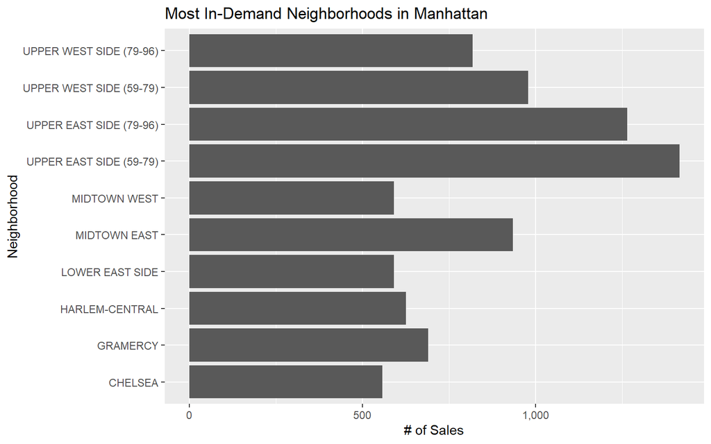

```r
# Most-in-demand neighborhood.
df11 <- manhattan_clean %>%
  group_by(NEIGHBORHOOD) %>%
  summarise(count = n()) %>%
  arrange(desc(count)) %>%
  head(10)

p11 <- ggplot(df11, aes(x = `NEIGHBORHOOD`, y = count)) +
  geom_bar(stat = "identity") +
  coord_flip() +
  ggtitle("Most In-Demand Neighborhoods in Manhattan") +
  theme(legend.position = "bottom") +
  scale_y_continuous("# of Sales", labels = scales::comma) +
  scale_x_discrete("Neighborhood")

p11
```

*The most expensive neighborhoods in Manhattan*  
Most of the buildings in the top neighborhoods listed here are office buildings, such as the Midtown CBS, Fashion District, and Javits Center. Office buildings are typically of much larger sizes - think about the skyscrapers that dominate throughout Manhattan’s skyline. So, this result could also be verified through common sense.

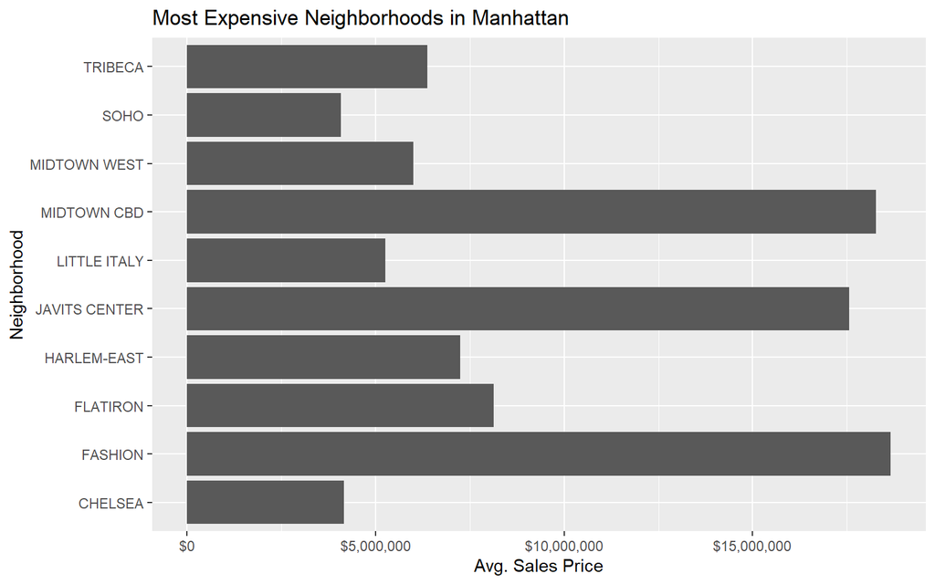

```r
# Most expensive neighborhood.
df12 <- manhattan_clean %>%
  group_by(NEIGHBORHOOD) %>%
  summarise(avgSP = mean(`SALE PRICE`)) %>%
  arrange(desc(avgSP)) %>%
  head(10)


p12 <- ggplot(df12, aes(x = `NEIGHBORHOOD`, y = avgSP)) +
  geom_bar(stat = "identity") +
  coord_flip() +
  theme(legend.position = "bottom") +
  ggtitle("Most Expensive Neighborhoods in Manhattan") +
  scale_y_continuous("Avg. Sales Price", labels = scales::dollar) +
  scale_x_discrete("Neighborhood")

p12
```

*The least expensive neighborhoods in Manhattan*  
Roosevelt Island is actually one of the newly developed areas in Manhattan. In despite of its great potential as more and more residential building projects are under progress, since it still lacks a well-built and well-organized enviroment for living and working, it makes sense that it results as one of the two least expensive neighborhoods.

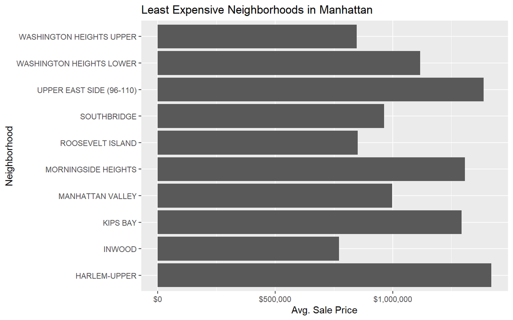

```r
# Least expensive neighborhood.
df13 <- manhattan_clean %>%
  group_by(NEIGHBORHOOD) %>%
  summarise(avgSP = mean(`SALE PRICE`)) %>%
  arrange(avgSP) %>%
  head(10)

p13 <- ggplot(df13, aes(x = `NEIGHBORHOOD`, y = avgSP)) +
  geom_bar(stat = "identity") +
  coord_flip() +
  theme(legend.position = "bottom") +
  ggtitle("Least Expensive Neighborhoods in Manhattan") +
  scale_y_continuous("Avg. Sale Price", labels = scales::dollar) +
  scale_x_discrete("Neighborhood")

p13
```

## Building Class Category

**The most in-demand, the most expensive and the least expensive building class categories in Manhattan.**

*The most in-demand building class categories in Manhattan*  
This result is unsurprising. Due to the large population that Manhattan carries, high-rise apartment buildings are also the most popular ones in Manhattan in regards to real estate. Some interesting findings from this graph are walk-up apartments and condo coops buildings are also of relatively high demands - these two categories are the upcomers in the Manhattan real estate market over these past few years. Many renovated walk up and condo coop buildings are presented in areas with strict regulation in terms of the height of building, such as the Hell’s Kitchen area around Midtown West.

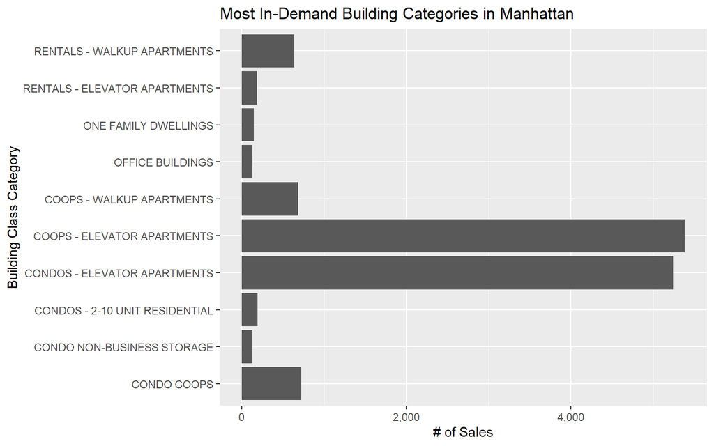

```r
# Most-in-demand building class.
df21 <- manhattan_clean %>%
  group_by(`BUILDING CLASS CATEGORY`) %>%
  summarise(count = n()) %>%
  arrange(desc(count)) %>%
  head(10)

p11 <- ggplot(df21, aes(x = `BUILDING CLASS CATEGORY`, y = count)) +
  geom_bar(stat = "identity") +
  coord_flip() +
  ggtitle("Most In-Demand Building Categories in Manhattan") +
  theme(legend.position = "bottom") +
  scale_y_continuous("# of Sales", labels = scales::comma) +
  scale_x_discrete("Building Class Category")

p11
```

*The most expensive building class categories in Manhattan*  
One interesting takeaway from this graph is that luxury hotels are actually the most pricey ones in the property market in Manhattan. The runner-up office building here is of no surprise. Another interesting point is that education facilities are also of high prices - this might be due to the many institutions scattered across town.

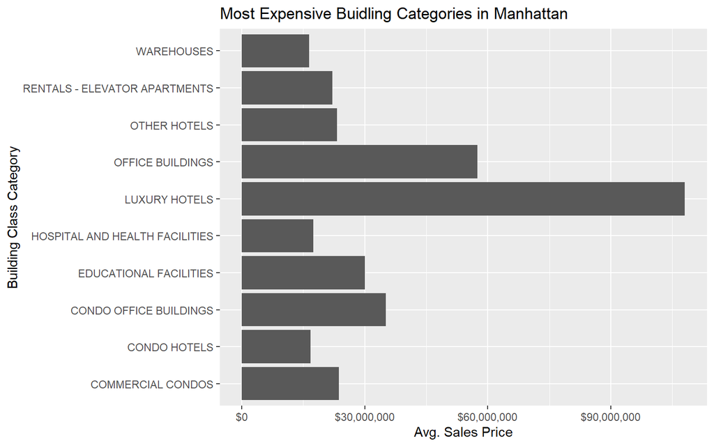

```r
# Most expensive neighborhood.
df22 <- manhattan_clean %>%
  group_by(`BUILDING CLASS CATEGORY`) %>%
  summarise(avgSP = mean(`SALE PRICE`)) %>%
  arrange(desc(avgSP)) %>%
  head(10)


p22 <- ggplot(df22, aes(x = `BUILDING CLASS CATEGORY`, y = avgSP)) +
  geom_bar(stat = "identity") +
  coord_flip() +
  theme(legend.position = "bottom") +
  ggtitle("Most Expensive Buidling Categories in Manhattan") +
  scale_y_continuous("Avg. Sales Price", labels = scales::dollar) +
  scale_x_discrete("Building Class Category")

p22
```

*The least expensive building class categories in Manhattan*  
The takeaway from this graph is that the zeroes prices shown (or extremely low prices, not shown in detail here because of the relatively large scale) for properties like asylums and houses. More background information would be needed to interpret this result.

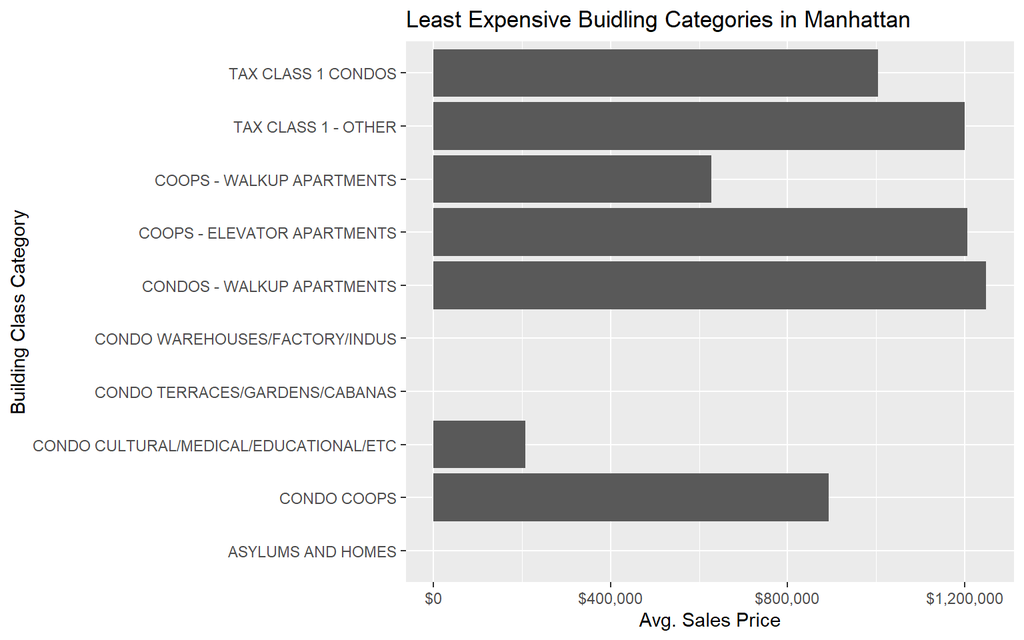

```r
# Least expensive neighborhood.
df23 <- manhattan_clean %>%
  group_by(`BUILDING CLASS CATEGORY`) %>%
  summarise(avgSP = mean(`SALE PRICE`)) %>%
  arrange(avgSP) %>%
  head(10)

p23 <- ggplot(df23, aes(x = `BUILDING CLASS CATEGORY`, y = avgSP)) +
  geom_bar(stat = "identity") +
  coord_flip() +
  theme(legend.position = "bottom") +
  ggtitle("Least Expensive Buidling Categories in Manhattan") +
  scale_y_continuous("Avg. Sales Price", labels = scales::dollar) +
  scale_x_discrete("Building Class Category")

p23
```

## Building Age

**The oldest neighborhoods and the youngest neighborhoods**

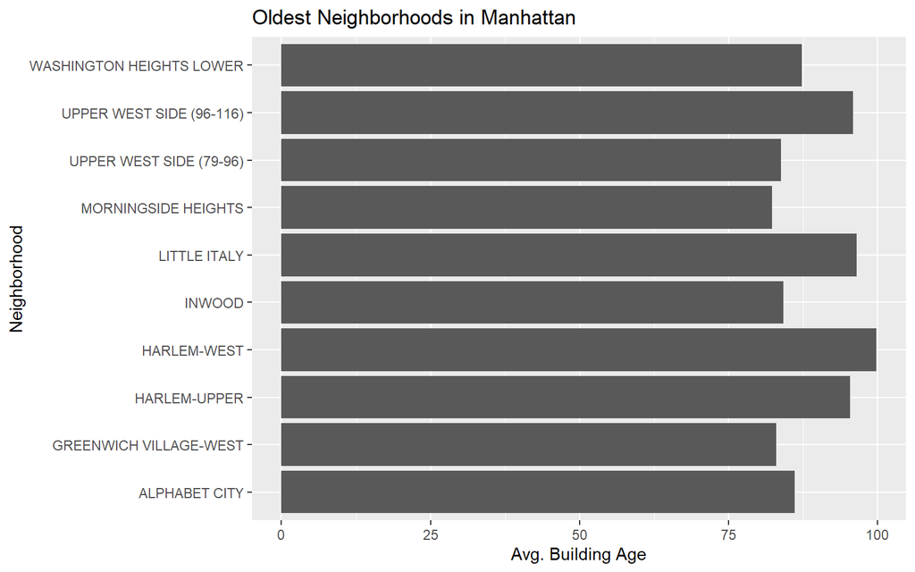

```r
#Oldest
df31 <- manhattan_clean %>%
  group_by(`NEIGHBORHOOD`) %>%
  summarise(avgAge = mean(`BUILDING AGE`)) %>%
  arrange(desc(avgAge))%>%
  head(10)

p31 <- ggplot(df31, aes(x = `NEIGHBORHOOD`, y = avgAge)) +
  geom_bar(stat = "identity") +
  coord_flip() +
  theme(legend.position = "bottom") +
  ggtitle("Oldest Neighborhoods in Manhattan") +
  scale_y_continuous("Avg. Building Age") +
  scale_x_discrete("Neighborhood")

p31
```

*The youngest neighborhoods*  
Again, this result echoes with the explanation of why properties on Roosevelt Island are of lower prices. Javits Center, however, is actually a pricey area. But because that area is largely composed of convention centers and transportation centers - the result makes sense.

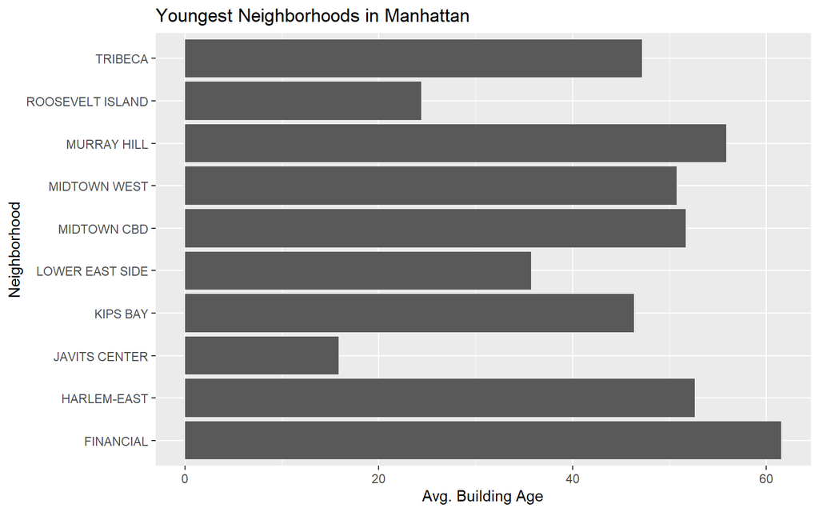

```r
#Youngest
df32 <- manhattan_clean %>%
  group_by(`NEIGHBORHOOD`) %>%
  summarise(avgAge = mean(`BUILDING AGE`)) %>%
  arrange(avgAge)%>%
  head(10)

p32 <- ggplot(df32, aes(x = `NEIGHBORHOOD`, y = avgAge)) +
  geom_bar(stat = "identity") +
  coord_flip() +
  theme(legend.position = "bottom") +
  ggtitle("Youngest Neighborhoods in Manhattan") +
  scale_y_continuous("Avg. Building Age") +
  scale_x_discrete("Neighborhood")

p32
```

**The oldest and newest types of building class category**

*The oldest types of building class category*  
The result is actually interesting to see a certain pattern how building styles have changed overtime. In recent years, the oldest buidling class categories such as loft buildings, walk-up buildings rarely have new manufacturing projects launced because they are not ideal to suit the demand of huge capabilities to accomodate more people.

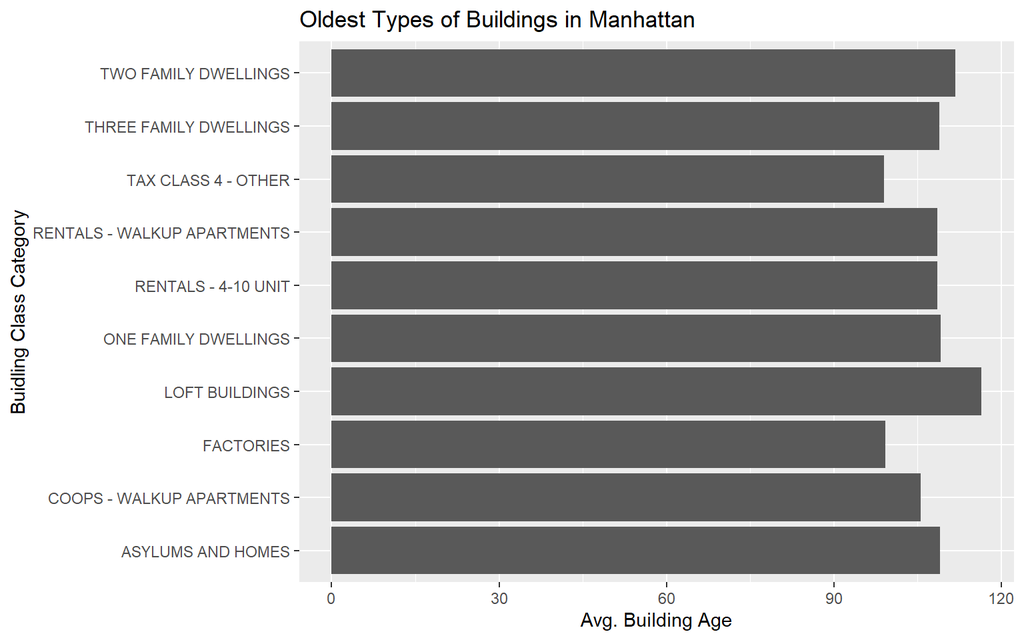

```r
df33 <- manhattan_clean %>%
  group_by(`BUILDING CLASS CATEGORY`) %>%
  summarise(avgAge = mean(`BUILDING AGE`)) %>%
  arrange(desc(avgAge))%>%
  head(10)

p33 <- ggplot(df33, aes(x = `BUILDING CLASS CATEGORY`, y = avgAge)) +
  geom_bar(stat = "identity") +
  coord_flip() +
  theme(legend.position = "bottom") +
  ggtitle("Oldest Types of Buildings in Manhattan") +
  scale_y_continuous("Avg. Building Age") +
  scale_x_discrete("Buidling Class Category")

p33
```

*The newest types of building class category*  
Parking and storage are actually among those recent demands of the new generation - which could be verified by this graph.

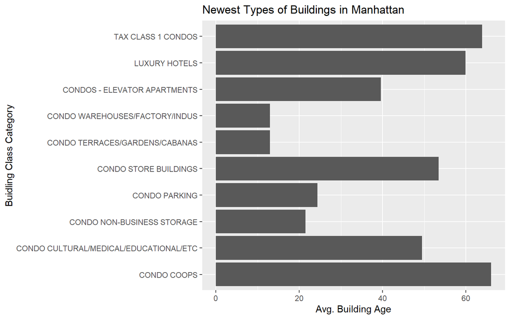

```r
df34 <- manhattan_clean %>%
  group_by(`BUILDING CLASS CATEGORY`) %>%
  summarise(avgAge = mean(`BUILDING AGE`)) %>%
  arrange(avgAge)%>%
  head(10)

p34 <- ggplot(df34, aes(x = `BUILDING CLASS CATEGORY`, y = avgAge)) +
  geom_bar(stat = "identity") +
  coord_flip() +
  theme(legend.position = "bottom") +
  ggtitle("Newest Types of Buildings in Manhattan") +
  scale_y_continuous("Avg. Building Age") +
  scale_x_discrete("Buidling Class Category")

p34
```

## Tax Class

Tax class at time of sale is a more valuable variable for this report, as it might influence the decision of buying properties to a certain extent.

**Tax class at time of sale versus the sale price**  
Due to the variety of data that this dataset includes, there are quite a lot of outliers that would affect the output of the boxplot. Especially, for tax class 4, the outlier situation is much more pronounced. So, a zoomed-in version of boxplot is created by limiting the range of the y-axis. From the latter graph, we could see that the median sale price for tax class 1 is higher than the medians for tax class 2 and 4. And from a closer look, the median sale price for tax class 4 is slightly lower.

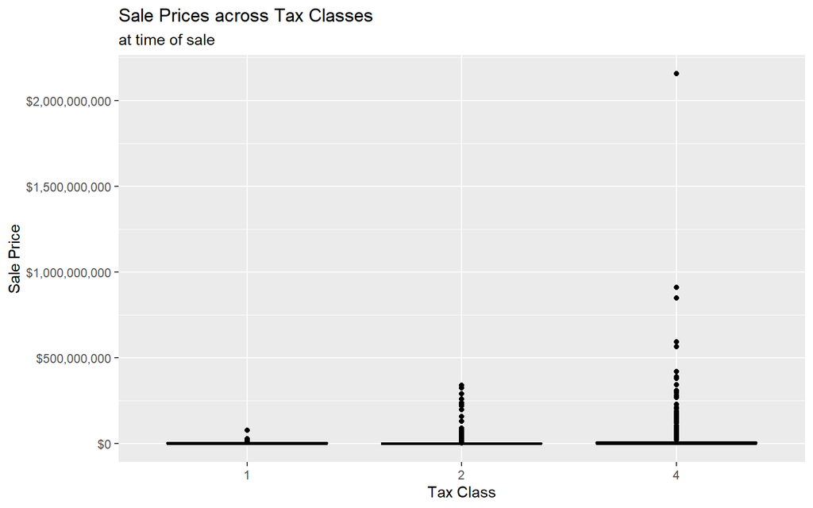

```r
p51 <- ggplot(manhattan_clean, mapping = aes(x = `TAX CLASS AT TIME OF SALE`, y = `SALE PRICE`, fill = `TAX CLASS AT TIME OF SALE`)) +
  geom_boxplot(fill='#A4A4A4', color="black") +
  ggtitle("Sale Prices across Tax Classes", subtitle = "at time of sale") +
  scale_y_continuous("Sale Price", labels = scales::dollar) +
  scale_x_discrete("Tax Class")

p51
```

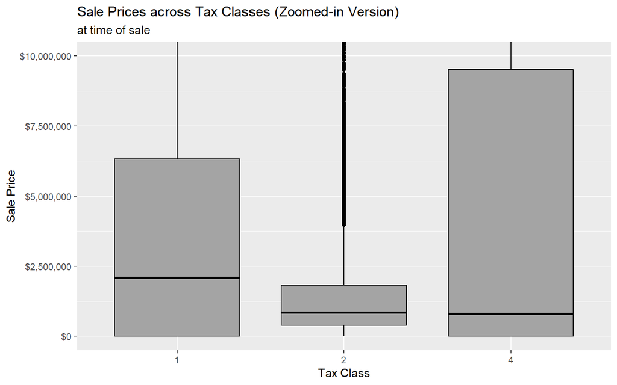

```r
p52 <- ggplot(manhattan_clean, mapping = aes(x = `TAX CLASS AT TIME OF SALE`, y = `SALE PRICE`, fill = `TAX CLASS AT TIME OF SALE`)) +
  geom_boxplot(fill='#A4A4A4', color="black") +
  coord_cartesian(ylim = c(0, 10000000)) +
  ggtitle("Sale Prices across Tax Classes (Zoomed-in Version)", subtitle = "at time of sale") +
  scale_y_continuous("Sale Price", labels = scales::dollar) +
  scale_x_discrete("Tax Class")

p52
```

## Time Series

This graph is created to see if there is a surge in property deals in terms of time of the year. From the result, some time near Feburary is the time when the market is most active; the second most active periods happen some time around June and July. However, since this graph depicts the result merely from November 2018 to November 2019, there might be concerns that this result is not representative. So, further analysis on this issue is performed in the predictive analysis section.

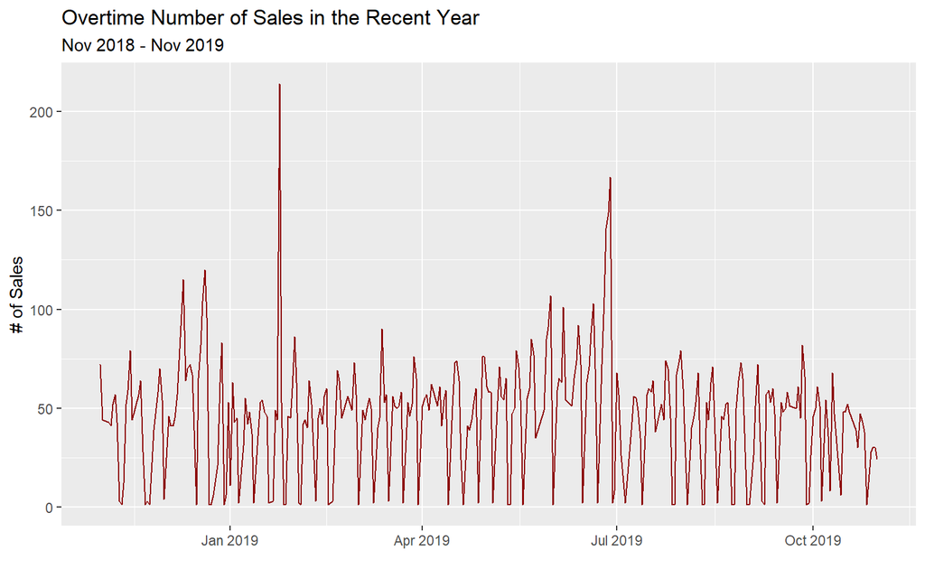

```r
df6 <- manhattan_clean %>%
  group_by(`SALE DATE`) %>%
  summarise (cbyyear = n())

p6 <- ggplot(df6, mapping = aes(x = `SALE DATE`, y = cbyyear)) +
  geom_line(color = "darkred") +
  ggtitle("Overtime Number of Sales in the Recent Year", subtitle = "Nov 2018 - Nov 2019") +
  scale_y_continuous("# of Sales", labels = scales::comma) +
  scale_x_date("")

p6
```

# Correlation

A correlation analysis is conducted to see if there is any collinearity exists among the variables. Since the dataset includes variables of various data types. The correlation analysis is conducted separately for numeric variables and categorical variables. Both a correlation table and a correlation plot are shown as follows.

## Correlation between numeric variables

One “big” finding from this part is that sale price is relatively more correlated to the gross square feet factor, in a positive direction. Plus, the number of residential units if more correlated to the number of total units, compared with the relationship between the number of commercial units and the number of total units.

```r
manhattan_corr2 <- manhattan_clean %>%
  mutate(`NEIGHBORHOOD` = as.factor(`NEIGHBORHOOD`))

correl <- cor(manhattan_corr2[sapply(manhattan_corr2, is.numeric)], use = "complete.obs")

round(correl, 3)
```

```
##                   RESIDENTIAL UNITS COMMERCIAL UNITS TOTAL UNITS
## RESIDENTIAL UNITS             1.000            0.028       0.900
## COMMERCIAL UNITS              0.028            1.000       0.462
## TOTAL UNITS                   0.900            0.462       1.000
## LAND SQUARE FEET              0.566            0.249       0.611
## GROSS SQUARE FEET             0.411            0.298       0.495
## SALE PRICE                    0.166            0.151       0.213
## BUILDING AGE                  0.013            0.031       0.025
##                   LAND SQUARE FEET GROSS SQUARE FEET SALE PRICE
## RESIDENTIAL UNITS            0.566             0.411      0.166
## COMMERCIAL UNITS             0.249             0.298      0.151
## TOTAL UNITS                  0.611             0.495      0.213
## LAND SQUARE FEET             1.000             0.671      0.298
## GROSS SQUARE FEET            0.671             1.000      0.505
## SALE PRICE                   0.298             0.505      1.000
## BUILDING AGE                 0.072            -0.003     -0.013
##                   BUILDING AGE
## RESIDENTIAL UNITS        0.013
## COMMERCIAL UNITS         0.031
## TOTAL UNITS              0.025
## LAND SQUARE FEET         0.072
## GROSS SQUARE FEET       -0.003
## SALE PRICE              -0.013
## BUILDING AGE             1.000
```

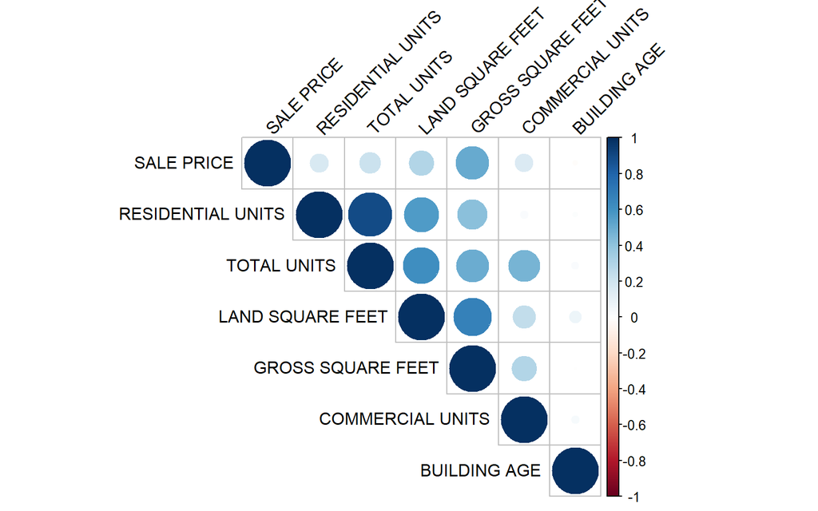

```r
corrplot(correl, type = "upper",order = "hclust",
         tl.col = "black", tl.srt = 45)
```

## Correlation between categorical variables

The takeaway from this correlation is that neighboorhood is not necessarily that much correlated to all the other categorical variables - which implies the property sales in each of the neighborhoods are pretty diverse at its own.

```r
cate <- manhattan_corr2[,c(1, 2, 3, 16, 17, 21)]
num <- c(1:6)
cate %<>% mutate_at(num, funs(as.numeric(.)))
round(cor(cate), 3)
```

```
##                                NEIGHBORHOOD BUILDING CLASS CATEGORY NUM
## NEIGHBORHOOD                          1.000                      -0.064
## BUILDING CLASS CATEGORY NUM          -0.064                       1.000
## BUILDING CLASS CATEGORY              -0.079                      -0.500
## TAX CLASS AT TIME OF SALE            -0.049                       0.786
## BUILDING CLASS AT TIME OF SALE       -0.116                       0.573
## SALE MONTH                            0.002                      -0.019
##                                BUILDING CLASS CATEGORY
## NEIGHBORHOOD                                    -0.079
## BUILDING CLASS CATEGORY NUM                     -0.500
## BUILDING CLASS CATEGORY                          1.000
## TAX CLASS AT TIME OF SALE                       -0.234
## BUILDING CLASS AT TIME OF SALE                  -0.497
## SALE MONTH                                      -0.002
##                                TAX CLASS AT TIME OF SALE
## NEIGHBORHOOD                                      -0.049
## BUILDING CLASS CATEGORY NUM                        0.786
## BUILDING CLASS CATEGORY                           -0.234
## TAX CLASS AT TIME OF SALE                          1.000
## BUILDING CLASS AT TIME OF SALE                     0.240
## SALE MONTH                                        -0.014
##                                BUILDING CLASS AT TIME OF SALE SALE MONTH
## NEIGHBORHOOD                                           -0.116      0.002
## BUILDING CLASS CATEGORY NUM                             0.573     -0.019
## BUILDING CLASS CATEGORY                                -0.497     -0.002
## TAX CLASS AT TIME OF SALE                               0.240     -0.014
## BUILDING CLASS AT TIME OF SALE                          1.000     -0.018
## SALE MONTH                                             -0.018      1.000
```

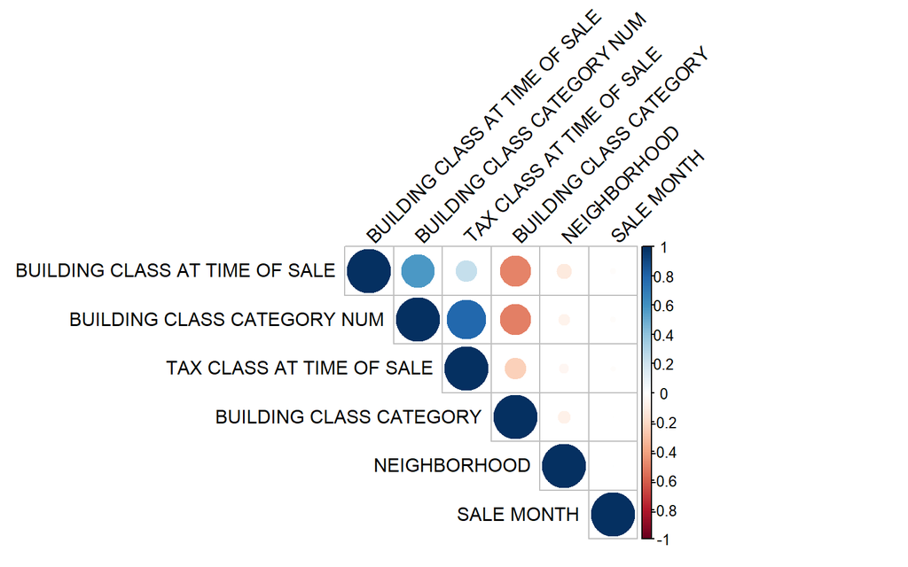

```r
corrplot(cor(cate), type = "upper",order = "hclust",
         tl.col = "black", tl.srt = 45)
```

## Conclusion

The correlations are pretty strong for certian variables, but this is due to the nature of how this dataset was originally collected.

# Analysis: ANOVA

To better conduct the predictive analysis, “Neighborhood” here is converted to “factor”.

```r
manhattan_pred <- manhattan_clean %>%
  mutate(`NEIGHBORHOOD` = as.factor(`NEIGHBORHOOD`))
```

**Four ANOVA tests are run to test the following answers.**  
*1. Does there exist any significant difference in sale prices among properties in different neighborhoods?*  
*2. Does there exist any significant difference in sale prices among different months of the year?*  
*3. Does there exist any significant difference in sale price among different building classes?*  
*4. Does there exist any significant difference in sale price among different tax classes at the time of sale?*

## Sale Prices and Neighborhood

To test the hypothesis of:  
*H0: There is no significant difference in sale prices among properties in different neighborhoods.*  
*H1: There exist certain ignificant differences in sale prices among properties in different neighborhoods.*

**Result:** As the p-value is extremely small, we could reject the null hypothesis and conclude that neighborhood really matters when it comes to the sale prices of properties.

```r
mod1 <- aov(`SALE PRICE` ~ `NEIGHBORHOOD`, data = manhattan_pred)
summary(mod1)
```

```
##                 Df    Sum Sq   Mean Sq F value Pr(>F)
## NEIGHBORHOOD    38 1.538e+17 4.048e+15   5.932 <2e-16 ***
## Residuals    14373 9.808e+18 6.824e+14
## ---
## Signif. codes:  0 '***' 0.001 '**' 0.01 '*' 0.05 '.' 0.1 ' ' 1
```

## Sale Prices and Sale Date (Month of the Year)

To test the hypothesis of:  
*H0: There is no significant difference in sale prices among different months of the year.*  
*H1: There exist certain significant differences in sale prices among different months of the* year.*

```r
mod2 <- aov(`SALE PRICE` ~ `SALE DATE`, data = manhattan_pred)

summary(mod2)
```

```
##                Df    Sum Sq   Mean Sq F value Pr(>F)
## `SALE DATE`     1 1.496e+14 1.496e+14   0.216  0.642
## Residuals   14410 9.961e+18 6.913e+14
```

## Sale Prices and Buidling Class Category

To test the hypothesis of:  
*H0: There is no significant difference in sale prices among different types of buildings sold.*  
*H1: There exist certain significant differences in sale prices among different types of buildings sold.*

**Result:** As the p-value is extremely small, we could reject the null hypothesis and conclude that there exist certain significant differences in sale prices among different types of buildings sold. This finding is quite intuitive as the class categories of the building determine quite many crucial indicator factors of the property such as the sizes, and etc.

```r
mod3 <- aov(`SALE PRICE` ~ `BUILDING CLASS CATEGORY`, data = manhattan_pred)
summary(mod3)
```

```
##                              Df    Sum Sq   Mean Sq F value Pr(>F)
## `BUILDING CLASS CATEGORY`    39 7.891e+17 2.023e+16    31.7 <2e-16 ***
## Residuals                 14372 9.172e+18 6.382e+14
## ---
## Signif. codes:  0 '***' 0.001 '**' 0.01 '*' 0.05 '.' 0.1 ' ' 1
```

## Sale Prices and Tax Class at Time of Sale

To test the hypothesis of:  
*H0: There is no significant difference in sale prices among the different tax classes at time of sale.*  
*H1: There exist certain significant differences in sale prices among the different tax classes at time of sale.*

**Result:** As the p-value is extremely small, we could reject the null hypothesis and conclude that there exist certain significant differences in sale prices among the different tax classes at time of sale.

```r
mod10 <- aov(`SALE PRICE` ~ `TAX CLASS AT TIME OF SALE`, data = manhattan_pred)
summary(mod10)
```

```
##                                Df    Sum Sq   Mean Sq F value Pr(>F)
## `TAX CLASS AT TIME OF SALE`     2 3.457e+17 1.728e+17     259 <2e-16 ***
## Residuals                   14409 9.616e+18 6.674e+14
## ---
## Signif. codes:  0 '***' 0.001 '**' 0.01 '*' 0.05 '.' 0.1 ' ' 1
```

# Analysis: Linear Regression

## Sale Price and Gross Square Feet

To test the hypothesis of:  
*H1: Sale price increases with the increase of gross square feet.*  
*H0: Gross square feet does not impact the sale price.*

**Results:** As the p-value being extremely small and the t-value being high, we could reject the null hypothesis. And from the coefficient, we could see that there is a positive relationship that as gross square feet goes higher, the sale price goes higher.

```r
mod4 <- lm(`SALE PRICE` ~ `GROSS SQUARE FEET`, data = manhattan_pred)
summary(mod4)
```

```
##
## Call:
## lm(formula = `SALE PRICE` ~ `GROSS SQUARE FEET`, data = manhattan_pred)
##
## Residuals:
##        Min         1Q     Median         3Q        Max
## -448252369   -1306558    -841558      71324 1747531295
##
## Coefficients:
##                      Estimate Std. Error t value Pr(>|t|)
## (Intercept)         1.582e+06  1.907e+05   8.292   <2e-16 ***
## `GROSS SQUARE FEET` 3.434e+02  4.886e+00  70.277   <2e-16 ***
## ---
## Signif. codes:  0 '***' 0.001 '**' 0.01 '*' 0.05 '.' 0.1 ' ' 1
##
## Residual standard error: 22690000 on 14410 degrees of freedom
## Multiple R-squared:  0.2553, Adjusted R-squared:  0.2552
## F-statistic:  4939 on 1 and 14410 DF,  p-value: < 2.2e-16
```

**Regression Diagnosis Plot**

From the diagnosis plot, there are quite a lot of outliers which are influencing the result of the model.

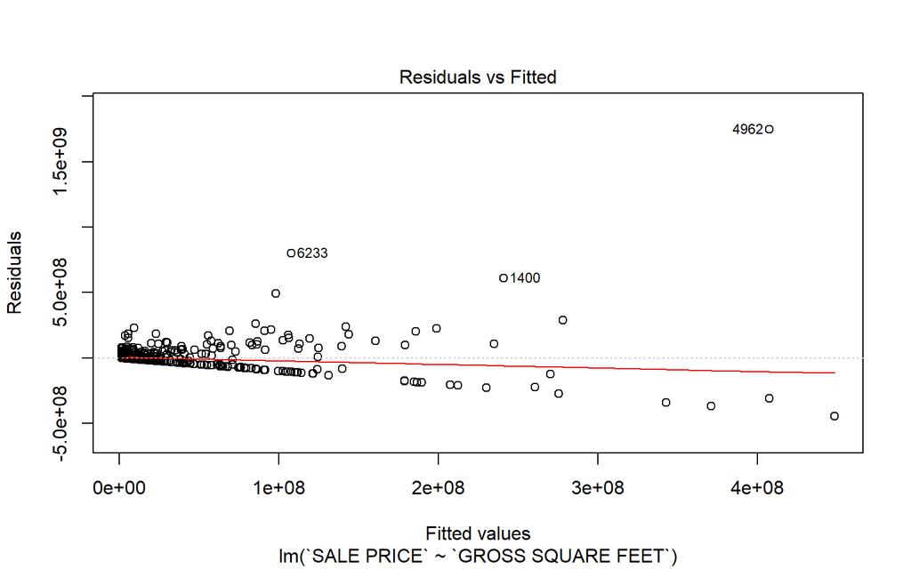

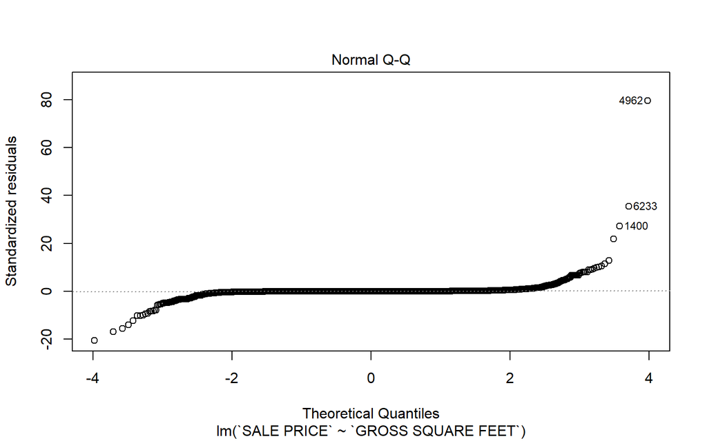

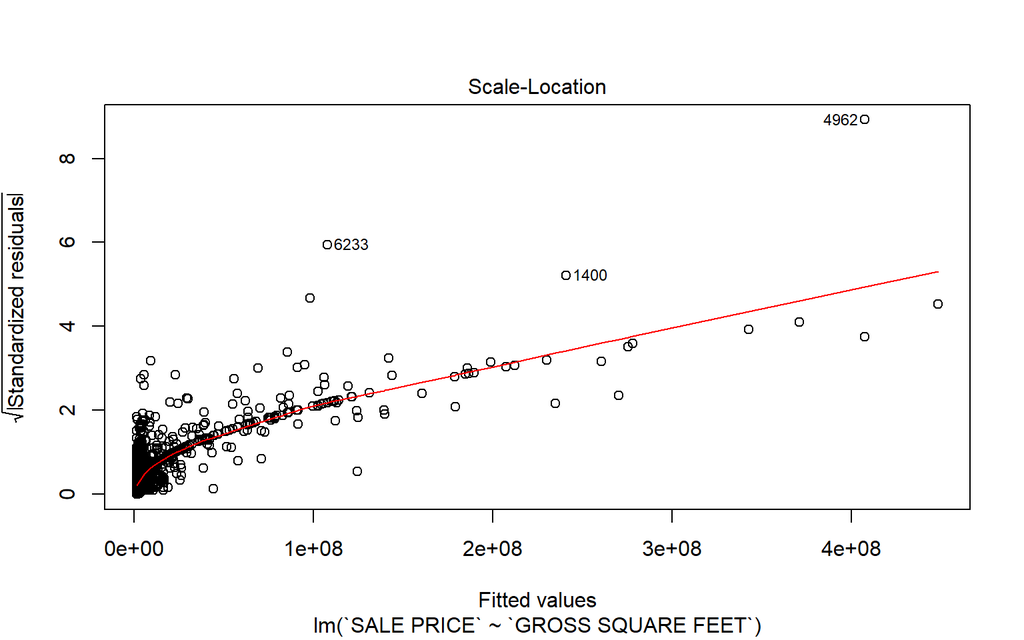

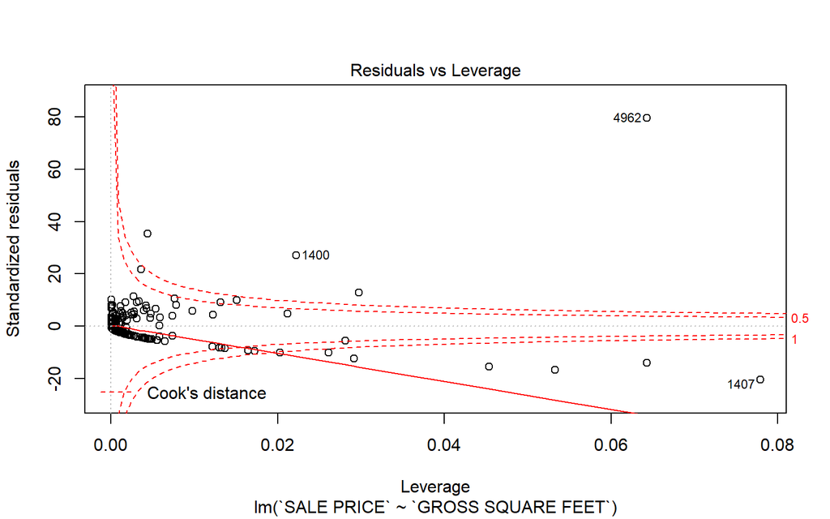

```r
plot(mod4)
```

**Post Hoc Power Analysis:**

The sample size is sufficiently enough.

```r
f2value1 = 0.2552 / (1-0.2552)
f2value1
```

```
## [1] 0.3426423
```

```r
fpower1 = pwr.f2.test(u = 1, v = 14410, f2 = f2value1, power = NULL)
fpower1
```

```
##
##      Multiple regression power calculation
##
##               u = 1
##               v = 14410
##              f2 = 0.3426423
##       sig.level = 0.05
##           power = 1
```

## Sale Price and Land Square Feet

To test the hypothesis of:  
*H1: Sale price increases with the increase of land square feet.*  
*H0: Land square feet does not impact the sale price.*

**Results:**As the p-value being extremely small and the t-value being high, we could reject the null hypothesis. And from the coefficient, we could see that there is a positive relationship that as land square feet goes higher, the sale price goes higher.

```r
mod5 <- lm(`SALE PRICE` ~ `LAND SQUARE FEET`, data = manhattan_pred)
summary(mod5)
```

```
##
## Call:
## lm(formula = `SALE PRICE` ~ `LAND SQUARE FEET`, data = manhattan_pred)
##
## Residuals:
##        Min         1Q     Median         3Q        Max
## -191849699   -1822482   -1242482    -287482 2152962518
##
## Coefficients:
##                     Estimate Std. Error t value Pr(>|t|)
## (Intercept)        2.037e+06  2.121e+05   9.604   <2e-16 ***
## `LAND SQUARE FEET` 2.322e+03  6.204e+01  37.431   <2e-16 ***
## ---
## Signif. codes:  0 '***' 0.001 '**' 0.01 '*' 0.05 '.' 0.1 ' ' 1
##
## Residual standard error: 25100000 on 14410 degrees of freedom
## Multiple R-squared:  0.08861,    Adjusted R-squared:  0.08855
## F-statistic:  1401 on 1 and 14410 DF,  p-value: < 2.2e-16
```

**Regression Diagnosis Plot**

From the diagnosis plot, there are quite a lot of outliers which are influencing the result of the model.

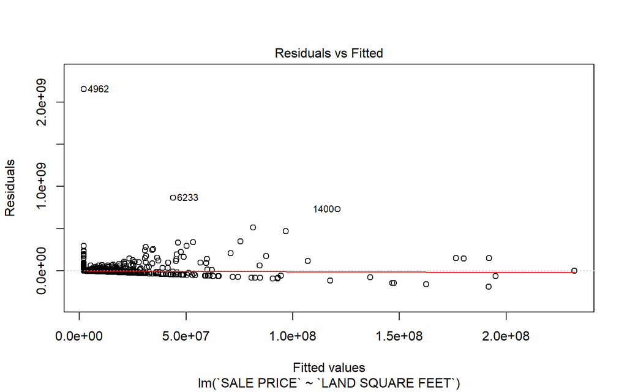

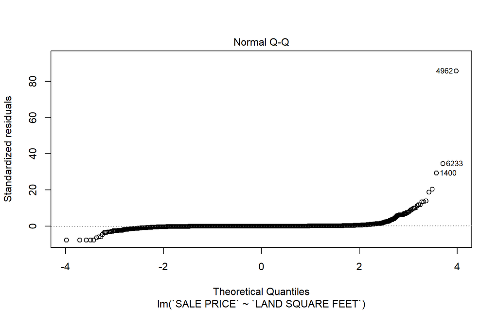

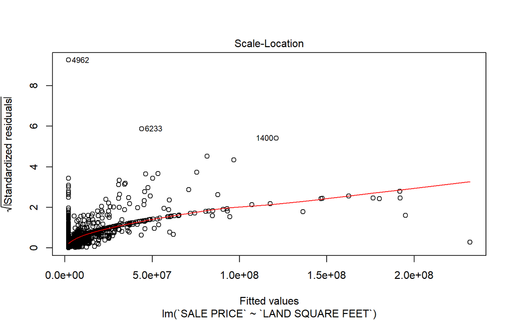

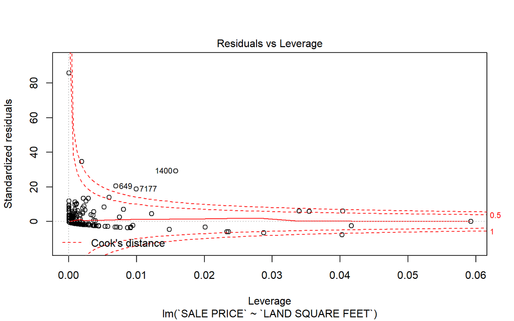

```r
# outlier
plot(mod5)
```

**Post Hoc Power Analysis:**

The power returned is 1, which means the sample size is sufficiently enough.

```r
#power analysis
f2value2 = 0.08855 / (1-0.08855)
f2value2
```

```
## [1] 0.09715289
```

```r
fpower2 = pwr.f2.test(u = 1, v = 14410, f2 = f2value2, power = NULL)
fpower2
```

```
##
##      Multiple regression power calculation
##
##               u = 1
##               v = 14410
##              f2 = 0.09715289
##       sig.level = 0.05
##           power = 1
```

## Comparison of Land Square Feet and Gross Square Feet’s Impact on Sale Price

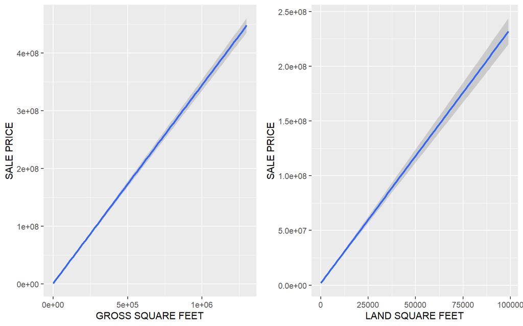

```r
pp1 <- ggplot(manhattan_pred) +
  geom_smooth(method = lm, aes(`GROSS SQUARE FEET`, `SALE PRICE`))

pp2 <- ggplot(manhattan_pred) +
  geom_smooth(method = lm, aes(`LAND SQUARE FEET`, `SALE PRICE`))

# Put all three plots altogether.
grid.arrange(pp1, pp2, nrow =1)
```

## Sale Price and Building Age

To test the hypothesis of:  
*H1: Sale price decrease as the building age gets higher.*  
*H0: Building age does not impact the sale price.*

**Results:** As the p-value being not small enough and as the t-value is not large, we could not reject the null hypothesis. Given the information we have here, we could conclude that building age does not really cause significant differences in sale prices of property

```r
mod6 <- lm(`SALE PRICE` ~ `BUILDING AGE`, data = manhattan_pred)
summary(mod6)
```

```
##
## Call:
## lm(formula = `SALE PRICE` ~ `BUILDING AGE`, data = manhattan_pred)
##
## Residuals:
##        Min         1Q     Median         3Q        Max
##   -3961094   -2972455   -2496184   -1457619 2151065568
##
## Coefficients:
##                Estimate Std. Error t value Pr(>|t|)
## (Intercept)     3969982     445119   8.919   <2e-16 ***
## `BUILDING AGE`    -8887       5839  -1.522    0.128
## ---
## Signif. codes:  0 '***' 0.001 '**' 0.01 '*' 0.05 '.' 0.1 ' ' 1
##
## Residual standard error: 26290000 on 14410 degrees of freedom
## Multiple R-squared:  0.0001608,  Adjusted R-squared:  9.138e-05
## F-statistic: 2.317 on 1 and 14410 DF,  p-value: 0.128
```

## Sale Price and Commercial Units

To test the hypothesis of:  
*H1: Sale price increases with the increase of the number of commercial units.*  
*H0: The number of commercial units does not impact the sale price.*

**Results:** From the result, as the p-value is small, and t-value is relatively large, we could reject the null hypothesis. And from the coefficient, we could see that sale price does increase with the increase of the number of commercial units.

```r
mod7 <- lm(`SALE PRICE` ~ `COMMERCIAL UNITS`, data = manhattan_pred)
summary(mod7)
```

```
##
## Call:
## lm(formula = `SALE PRICE` ~ `COMMERCIAL UNITS`, data = manhattan_pred)
##
## Residuals:
##        Min         1Q     Median         3Q        Max
## -139813840   -2783014   -2283014   -1183014 2151866986
##
## Coefficients:
##                    Estimate Std. Error t value Pr(>|t|)
## (Intercept)         3133014     216935   14.44   <2e-16 ***
## `COMMERCIAL UNITS`   533903      29188   18.29   <2e-16 ***
## ---
## Signif. codes:  0 '***' 0.001 '**' 0.01 '*' 0.05 '.' 0.1 ' ' 1
##
## Residual standard error: 25990000 on 14410 degrees of freedom
## Multiple R-squared:  0.02269,    Adjusted R-squared:  0.02263
## F-statistic: 334.6 on 1 and 14410 DF,  p-value: < 2.2e-16
```

**Regression Diagnosis Plot**

From the diagnosis plot, there are quite a lot of outliers which are influencing the result of the model.

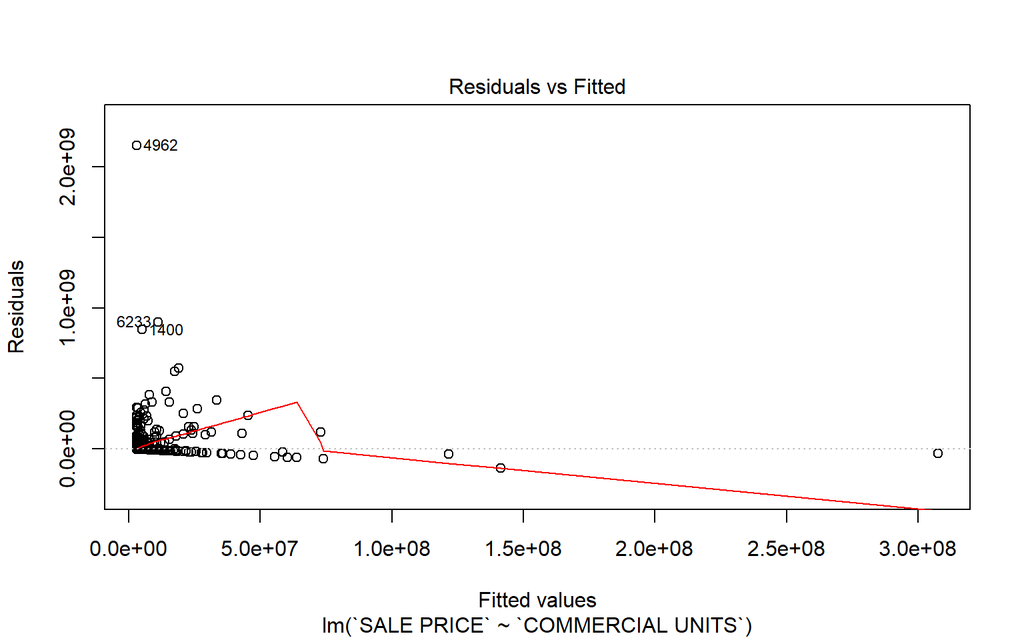

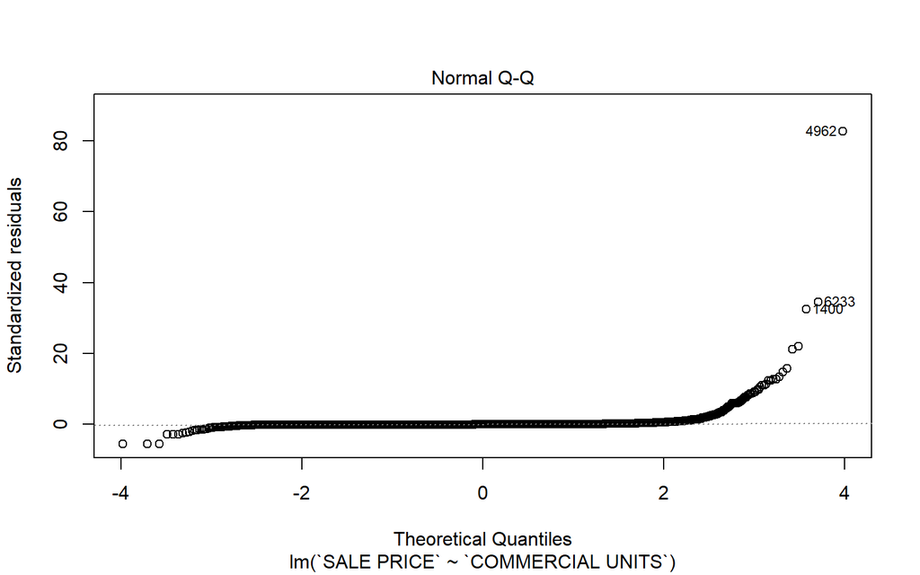

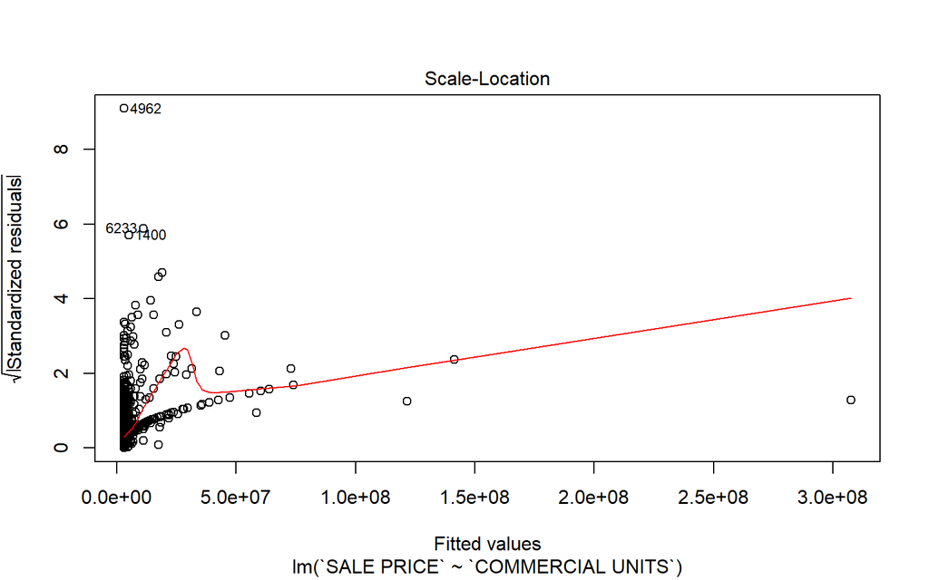

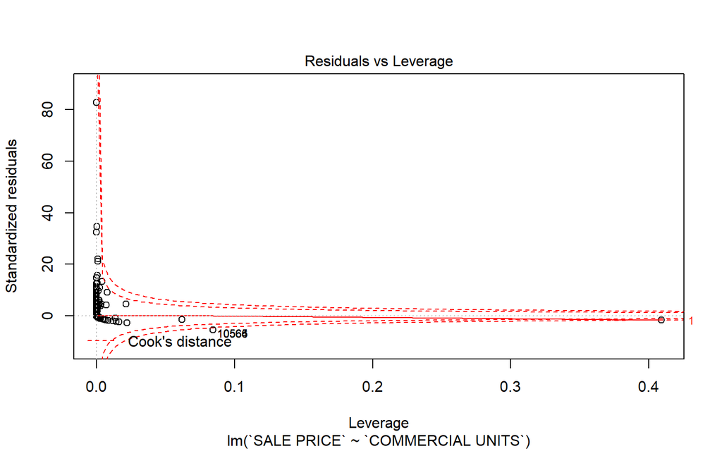

```r
#outlier
plot(mod7)
```

**Post Hoc Power Analysis:** The sample size is sufficiently enough.

```r
#power analysis
f2value3 = 0.02263 / (1-0.02263)
f2value3
```

```
## [1] 0.02315397
```

```r
fpower3 = pwr.f2.test(u = 1, v = 14410, f2 = f2value3, power = NULL)
fpower3
```

```
##
##      Multiple regression power calculation
##
##               u = 1
##               v = 14410
##              f2 = 0.02315397
##       sig.level = 0.05
##           power = 1
```